# PR1

Huy Tu

8/24/2015

# (i)

After at least 1000 trials, complete the table below.

```r
babies <- c("Marvin", "Willie", "Billy", "Sam")
nights <- 1000
NumberCorrect <- numeric(nights)
for(i in 1:nights){
  shuffle <- sample(babies, size = 4, replace = FALSE)
  NumberCorrect[i] <- sum(babies == shuffle)
}
xtabs(~NumberCorrect)
```

```
## NumberCorrect
##   0   1   2   4
## 382 347 227  44
```

```r
TAsi <- xtabs(~NumberCorrect)/nights
TAsi
```

```
## NumberCorrect
##     0     1     2     4
## 0.382 0.347 0.227 0.044
```

*The R simulation with 1,000 trials/nights returns and estimated probability that zero mothers receive thier own baby of 0.382.*

# (o)

How many different outcomes are there for returning four babies to their mothers? What is each outcome’s probability of occurring for any trial?

```r
library(combinat)
library(MASS)
Omega <- permn(babies)
n <- length(Omega) #
NumberCorrect <- numeric(n)
for(i in 1:n){
NumberCorrect[i] <- sum(Omega[[i]] == babies)
}
FA <- xtabs(~NumberCorrect)/n
FA
```

```
## NumberCorrect
##          0          1          2          4
## 0.37500000 0.33333333 0.25000000 0.04166667
```

```r
TA <- fractions(xtabs(~NumberCorrect)/n)
TA
```

```
## NumberCorrect
##    0    1    2    4
##  3/8  1/3  1/4 1/24
```

*There are 24 possible outcomes for returning the four babies to their mothers. The possible outcomes are stored in the variable `Omega`. The probability of each outcome is 1/24.*

```r
Omega
```

```
## [[1]]
## [1] "Marvin" "Willie" "Billy"  "Sam"
##
## [[2]]
## [1] "Marvin" "Willie" "Sam"    "Billy"
##
## [[3]]
## [1] "Marvin" "Sam"    "Willie" "Billy"
##
## [[4]]
## [1] "Sam"    "Marvin" "Willie" "Billy"
##
## [[5]]
## [1] "Sam"    "Marvin" "Billy"  "Willie"
##
## [[6]]
## [1] "Marvin" "Sam"    "Billy"  "Willie"
##
## [[7]]
## [1] "Marvin" "Billy"  "Sam"    "Willie"
##
## [[8]]
## [1] "Marvin" "Billy"  "Willie" "Sam"
##
## [[9]]
## [1] "Billy"  "Marvin" "Willie" "Sam"
##
## [[10]]
## [1] "Billy"  "Marvin" "Sam"    "Willie"
##
## [[11]]
## [1] "Billy"  "Sam"    "Marvin" "Willie"
##
## [[12]]
## [1] "Sam"    "Billy"  "Marvin" "Willie"
##
## [[13]]
## [1] "Sam"    "Billy"  "Willie" "Marvin"
##
## [[14]]
```

[output cut: 16 more lines]

```
##
## [[20]]
## [1] "Sam"    "Willie" "Billy"  "Marvin"
##
## [[21]]
## [1] "Sam"    "Willie" "Marvin" "Billy"
##
## [[22]]
## [1] "Willie" "Sam"    "Marvin" "Billy"
##
## [[23]]
## [1] "Willie" "Marvin" "Sam"    "Billy"
##
## [[24]]
## [1] "Willie" "Marvin" "Billy"  "Sam"
```

# Test

[output not shown]

# ISCAM Investigation 1.1: Friend or Foe?

1. What proportion of these infants chose the helper toy? Is this more than half (majority)? Alos sketch by hand a simple bar group to display the results for this sample (one bar for each toy, with heights representing the proportion of times taht toy was picked, bars are separated).

These infants chose the helper toy at the proportion of .875. This is definitely more than half (majority).

```r
dat <- data.frame(
  Choice = factor(c("Helper","Hinderer"), levels=c("Helper","Hinderer")),
  Proportion = c(.875, .125)
)
dat
```

```
##     Choice Proportion
## 1   Helper      0.875
## 2 Hinderer      0.125
```

[output not shown]

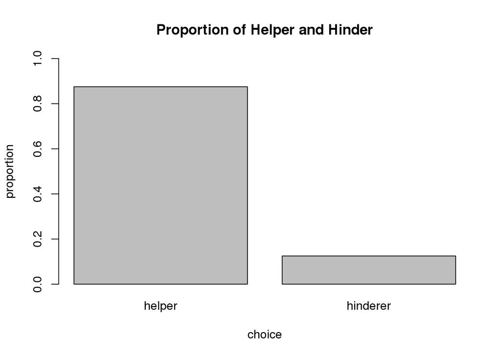

```r
# Load the ggplot2 package
library(ggplot2)
choice <- c(.875, .125)
barplot(choice, main="Proportion of Helper and Hinder", xlab="choice",
   ylab="proportion", names.arg=c("helper","hinderer"), border="black",ylim = c(0, 1))
```

6. Explain why looking at such “could have been” results will be useful to us.

The “could have been” results will provide a good representation of how a true random simulation would result. A bell curve with the center around 8. Consequently, the “could have been” results would show how unlikely 14 out of 16 would occur.

7. Flip a coin 16 times, representing the 16 infants in the study (one trial or repetition from this random process). Let a result of heads mean that the infant chooses the helper toy, tails for the hinderer toy. Tally the results below and count how many of the 16 chose the helper toy:

```r
heads <- sum(sample(0:1, 16, replace = TRUE))
tails <- (16 - heads)
```

8. Repeat this two more times. Keep track of how many infants, out of the 16, choose the helper. Record this number for all three of your repetitions (including the one from the previous question):